# Theory of Computation

Reagan Shirk

August 27, 2019

# Boolean Logic

- AND, OR, NOT, XOR, $\to$, $\iff$

| A | B | A $\land$ B | A $\to$ B | A $\iff$ B |
| --- | --- | --- | --- | --- |
| F | F | F | T | T |
| F | T | F | T | F |
| T | F | F | F | F |
| T | T | T | T | T |

- When two functions are different it means their outputs are different
  - i.e. AND should have at least one output different than OR
- For A $\iff$ B, when A is F and B is T, read from right to left. When A is T and B is F, read from left to right
  - i.e. start reading with the one that is false
- A $\subseteq$ B: $\forall$ x, if x $\in$ A then x $\in$ B
- 16 functions of 2 boolean varialbes ($2^4$, you have four combinations of 2)
  - 4 rows of the truth table and 2 options for each row
- How many boolean functions do we have on n boolean variables?
  - $2^{2^{n}}$

# Distributive Laws

- a(b + c) = (a + b)(a + c)
- P $\land$ (Q $\lor$ R) = (P $\land$ Q) $\lor$ (P $\land$ R)
- P $\lor$ (A $\land$ R) = (P $\lor$ Q) $\land$ (P $\lor$ R)

# Regular Languages

- As characters are read, they start following arrows into different states

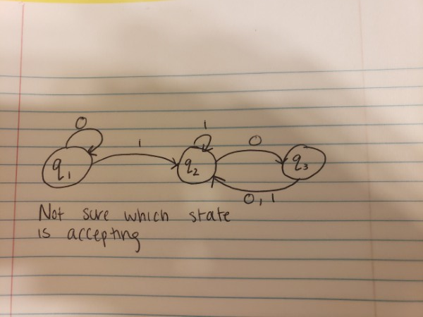

State Diagram

- Example Strings:
  - 00001 $\to$ accepted
  - 1001 $\to$ accepted
  - 0 $\to$ rejected
  - $\lambda \to$ rejected
  - $\lambda$ is the empty string

# Finite Automaton

- Specified by a 5-tuple
  - $Q, \Sigma, \delta, q_o, F$
    - $Q$ = finite set of states
    - $\Sigma$ = finite alphabet
    - $\delta$ = $Q \times \Sigma \to Q$ (transition function)
    - $q_o$ = starting state
    - $F$ = set of accepting states
  - The language of $M$ is $L(M) = A$ and that is the set of all strings accepted by $M$
  - We can also say that $M$ recognizes $A$ or $M$ accepts $A$
  - In our example…
    - $W$ ends with a 1, ends with an even number of 0s provided that you have at least one 1.
  - Language $A=\left\{w \in \left\{0, 1\right\}^{*} |w~has~an~even~number~of~0s\right\}$
    - the * after $\left\{0, 1\right\}$ means that you can concatenate as many functions (characters? I can’t remember) as you want
    - Two states, expressing the parity of 0s

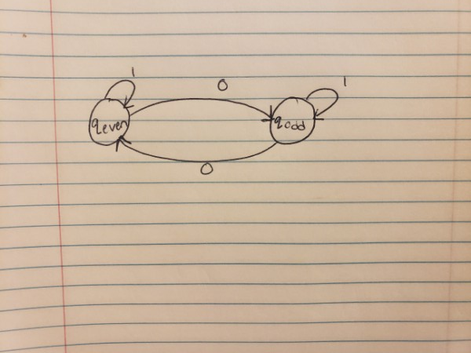

      State Diagram

[output not shown]

| $\delta$ | 0 | 1 |
| --- | --- | --- |
| $q_{even}$ | $q_{odd}$ | $q_{even}$ |
| $q_{odd}$ | $q_{even}$ | $q_{odd}$ |

- Language $B=\left\{w | w~ends~in~a~1~or~w=\lambda\right\}$

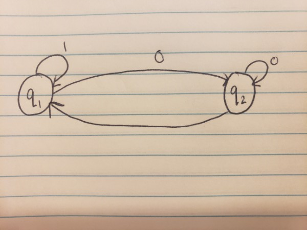

State Diagram

- Language $C=\left\{w|w~starts~with~and~ends~with~a~0~or~starts~with~and~ends~with~a~1\right\}$

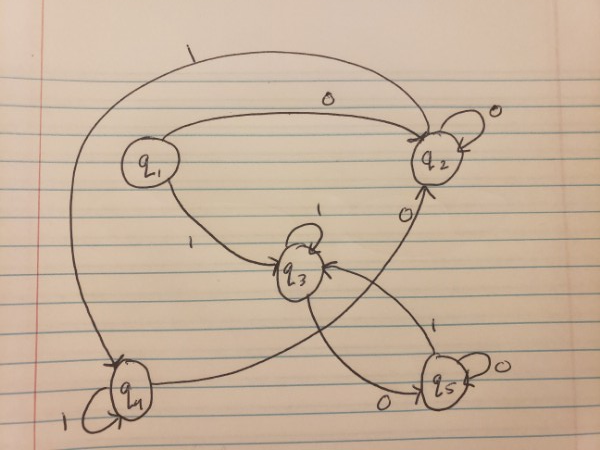

State Diagram

# Computation

# Regular Languages

- A language is called regular if there is some automaton that recognizes it

# Regular Operators

- Let $A$ and $B$ be languages. We define the regular operators $\cup$, $\circ$, $*$ as follows:
  - $\cup$: A $\cup$ B = $\left\{w~|~w \in A \lor w \in B\right\}$
  - $\circ$: A $\circ$ B = $\left\{w=xy~|~x \in A \land y \in B\right\}$
  - $*$: A$*$ = $\left\{w_1, w_2,...,w_k~|~w_i \in A \land k \geq 0\right\}$

# Theorem

- The class of regular languages is closed under the $\cup$ operation. In other words, if $A_1$ and $A_2$ are regular languages, then so is $A_1 \cup A_2$